# MasterDoc

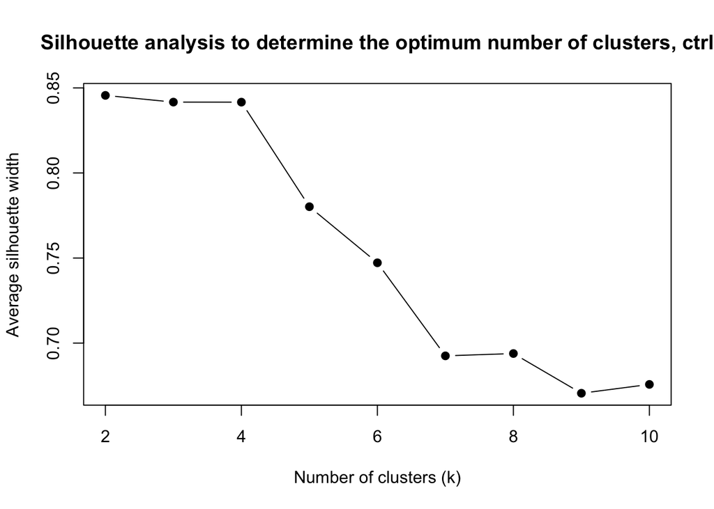

```r
# 1. Extract PCA-transformed data
ctrl_sil_df <- ctrl_pca$x

# 2. Placeholder for average silhouette widths
ctrl_avg_sil <- numeric(length = 9)  # for k = 2 to 10

# 3. Calculate silhouette scores for different k values
k_values <- 2:10
for (i in seq_along(k_values)) {
  k <- k_values[i]
  ctrl_km <- kmeans(ctrl_sil_df, centers = k, nstart = 25)
  ctrlc_ss <- silhouette(ctrl_km$cluster, dist(ctrl_sil_df))
  ctrl_avg_sil[i] <- mean(ctrlc_ss[, 3])
}

# 4. Plot similar to elbow method
plot(k_values, ctrl_avg_sil, type = "b", pch = 19,
     xlab = "Number of clusters (k)",
     ylab = "Average silhouette width",
     main = "Silhouette analysis to determine the optimum number of clusters, ctrl")
```

```
##   cluster size ave.sil.width
## 1       1 3551          0.88
## 2       2  129         -0.14
```

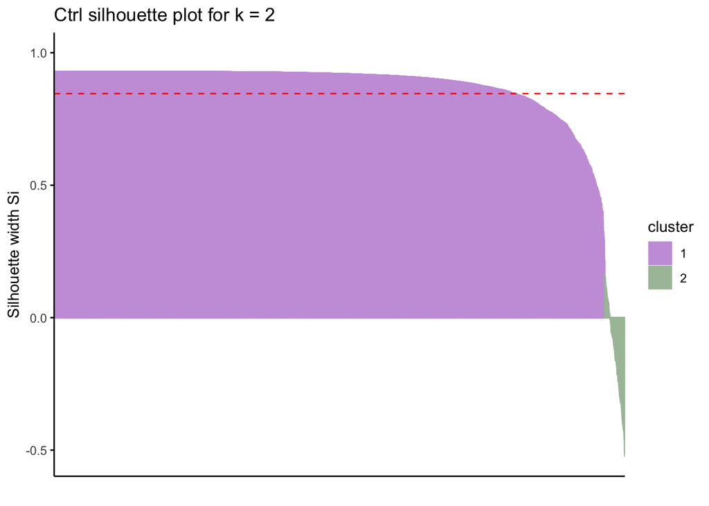

```r
# 5. Identify best k based on max silhouette width
best_k <- k_values[which.max(ctrl_avg_sil)]

# 6. Run KMeans and compute silhouette for best k
km_best <- kmeans(ctrl_sil_df, centers = best_k, nstart = 25)
ctrl_best_sil <- silhouette(km_best$cluster, dist(ctrl_sil_df))

# 7. Visualize silhouette plot
fviz_silhouette(
  ctrl_best_sil,
  palette = c("#c9a0dc", "#A9C1A6"),
  ggtheme = theme_classic(),
  main = paste("Ctrl silhouette plot for k =", best_k)
)
```

#Interpretation k=2 seems most suitable

###kmeans Goal:divide dataset into k cluster to understand grouping and potentionally find biological relations

```r
#1. apply kmeans to reduced data set
# using k=2
#kmeans runs 25 and uses best result
C_kmeans_result <- kmeans(ctrl_pca$x, centers = 2, nstart = 25)
```

```r
#1. in which cluster every obserbation is assigned to
head(C_kmeans_result$cluster)
```

```
## [1] 1 1 1 2 1 1
```

```r
#2. coordinates the cluster center
head(C_kmeans_result$centers)
```

```
##          PC1         PC2          PC3         PC4           PC5          PC6
## 1 -0.8247357  0.02821534 -0.009207861 -0.01320268 -0.0007150378  0.006327941
## 2 22.7026086 -0.77668735  0.253465995  0.36343201  0.0196829410 -0.174190071
##           PC7          PC8           PC9         PC10         PC11         PC12
## 1  0.00503068  0.004002011  0.0009881708 -0.006426645 -0.005171679 -0.003295783
## 2 -0.13848020 -0.110163881 -0.0272015086  0.176907109  0.142361480  0.090723445
##          PC13         PC14          PC15         PC16         PC17
## 1 -0.01157518  0.003946248 -0.0004773928 -0.003334691  0.001520389
## 2  0.31863143 -0.108628900  0.0131412536  0.091794486 -0.041851938
##            PC18          PC19         PC20         PC21         PC22
## 1  0.0002810723  0.0007293193  0.001243313 -0.003691292 -0.003596162
## 2 -0.0077371148 -0.0200760696 -0.034224830  0.101610683  0.098992013
##            PC23         PC24          PC25         PC26          PC27
## 1  0.0007008899 -0.001743719 -3.856847e-05 -0.001610297  0.0001486219
## 2 -0.0192934892  0.047999574  1.061679e-03  0.044326864 -0.0040911338
##            PC28          PC29          PC30          PC31          PC32
## 1 -0.0004112154  7.181285e-05  0.0009897197 -0.0005850297 -0.0001851157
## 2  0.0113195792 -1.976802e-03 -0.0272441433  0.0161041894  0.0050957051
##            PC33          PC34          PC35          PC36          PC37
## 1 -0.0003376993 -0.0007299575 -0.0002285522  0.0002674778 -0.0004738191
## 2  0.0092958925  0.0200936350  0.0062913876 -0.0073628971  0.0130428820
##            PC38          PC39          PC40         PC41          PC42
## 1  0.0005665678  0.0003040577  0.0007757139 -0.000668126 -0.0000367055
## 2 -0.0155959869 -0.0083698377 -0.0213531781  0.018391593  0.0010103973
##            PC43         PC44          PC45          PC46          PC47
## 1 -4.478121e-05 -0.000633724 -0.0003647366  0.0001834876  0.0004086984
## 2  1.232698e-03  0.017444603  0.0100401522 -0.0050508870 -0.0112502960
##            PC48          PC49          PC50          PC51          PC52
## 1 -5.430099e-05 -8.345448e-05 -8.888072e-05 -0.0001903578  0.0001284457
## 2  1.494750e-03  2.297262e-03  2.446631e-03  0.0052400053 -0.0035357405
##            PC53          PC54          PC55          PC56          PC57
## 1  1.421648e-05 -0.0001596692  0.0001486461  0.0001606036  2.424676e-05
## 2 -3.913390e-04  0.0043952355 -0.0040918012 -0.0044209568 -6.674438e-04
##            PC58          PC59          PC60          PC61          PC62
## 1 -0.0001005235 -0.0001212691  4.804204e-05 -0.0001955719 -0.0001009009
## 2  0.0027671228  0.0033381903 -1.322459e-03  0.0053835348  0.0027775115
##            PC63          PC64          PC65          PC66          PC67
## 1  1.448945e-05  3.863389e-05  0.0001134993 -0.0001118753  0.0001226434
## 2 -3.988530e-04 -1.063480e-03 -0.0031243109  0.0030796069 -0.0033760219
##            PC68          PC69          PC70          PC71          PC72
## 1  3.864943e-05  5.686646e-06  5.679477e-05 -3.602067e-05  1.503079e-05
## 2 -1.063908e-03 -1.565371e-04 -1.563397e-03  9.915458e-04 -4.137545e-04
##            PC73          PC74          PC75
## 1 -1.254082e-15  4.422331e-16 -8.035192e-17
## 2  3.840775e-14 -5.702998e-15 -8.237407e-15
```

```r
#3. shows how compact the clusters are using WSS
# lower WSS means a more compact cluster
C_kmeans_result$tot.withinss
```

```
## [1] 206878.1
```

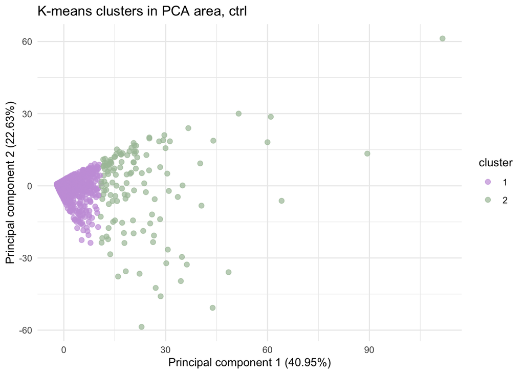

```r
#1. prepare data
#save pca matrix into data frame
# add cluster column
ctrl_data <- as.data.frame(ctrl_pca$x)
ctrl_data$cluster <- as.factor(C_kmeans_result$cluster)

#2. plot
library(ggplot2)

ggplot(ctrl_data, aes(x = PC1, y = PC2, color = cluster)) +
  geom_point(alpha = 0.7, size = 2) +
  labs(title = "K-means clusters in PCA area, ctrl",
       x = "Principal component 1 (40.95%)",
       y = "Principal component 2 (22.63%)") +
  theme_minimal() +
  scale_color_manual(values = c("#c9a0dc","#A9C1A6"))
```

#plot PC1 and PC2 as control

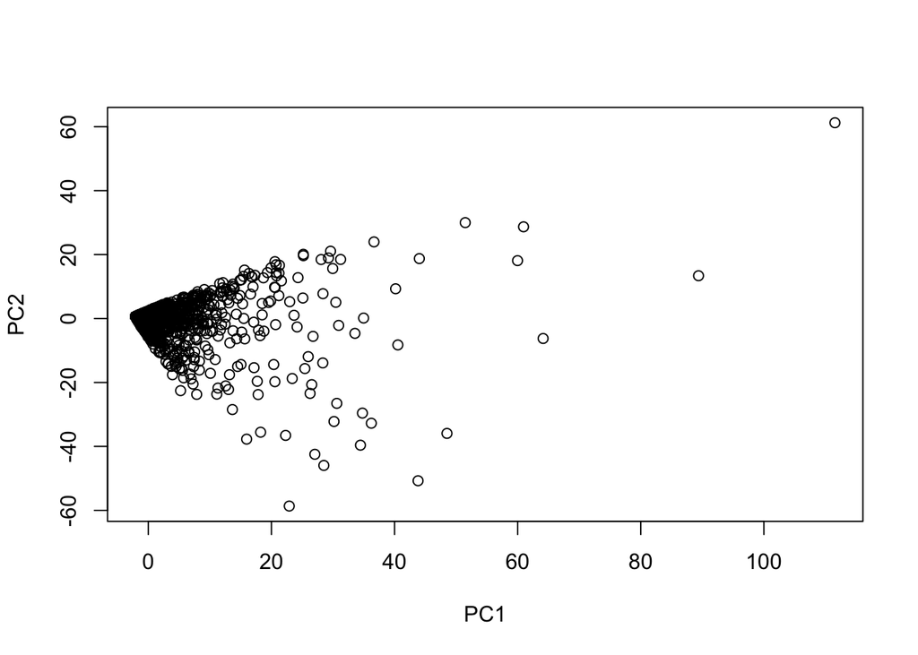

```r
first_two_components <- ctrl_data[,1:2]
plot(first_two_components)
```

###PCA RNASE

##Check how dataset is made up

```r
rnase_perc_df <- as.data.frame(percent_rnase_df[,-1])
rownames(rnase_perc_df) <- rnase_perc_df$X
R_TEST <- rnase_perc_df
# we have 3680 observations and 75 features
```

#Test data -> check if varibales are on the same scale

```r
apply(R_TEST, 2, mean)
```

```
##  Fraction1_Rep1  Fraction1_Rep2  Fraction1_Rep3  Fraction2_Rep1  Fraction2_Rep2
##        513.7528        513.7528        513.7528       1939.3825       1939.3825
##  Fraction2_Rep3  Fraction3_Rep1  Fraction3_Rep2  Fraction3_Rep3  Fraction4_Rep1
##       1939.3825       2992.7497       2992.7497       2992.7497       8076.3011
##  Fraction4_Rep2  Fraction4_Rep3  Fraction5_Rep1  Fraction5_Rep2  Fraction5_Rep3
##       8076.3011       8076.3011      16762.9605      16762.9605      16762.9605
##  Fraction6_Rep1  Fraction6_Rep2  Fraction6_Rep3  Fraction7_Rep1  Fraction7_Rep2
##      20678.3663      20678.3663      20678.3663      21014.8843      21014.8843
##  Fraction7_Rep3  Fraction8_Rep1  Fraction8_Rep2  Fraction8_Rep3  Fraction9_Rep1
##      21014.8843      13857.2422      13857.2422      13857.2422      11132.2350
##  Fraction9_Rep2  Fraction9_Rep3 Fraction10_Rep1 Fraction10_Rep2 Fraction10_Rep3
##      11132.2350      11132.2350       8005.4413       8005.4413       8005.4413
## Fraction11_Rep1 Fraction11_Rep2 Fraction11_Rep3 Fraction12_Rep1 Fraction12_Rep2
##       6550.8177       6550.8177       6550.8177       5293.5669       5293.5669
## Fraction12_Rep3 Fraction13_Rep1 Fraction13_Rep2 Fraction13_Rep3 Fraction14_Rep1
##       5293.5669       4367.4365       4367.4365       4367.4365       3751.0087
## Fraction14_Rep2 Fraction14_Rep3 Fraction15_Rep1 Fraction15_Rep2 Fraction15_Rep3
##       3751.0087       3751.0087       3353.4157       3353.4157       3353.4157
## Fraction16_Rep1 Fraction16_Rep2 Fraction16_Rep3 Fraction17_Rep1 Fraction17_Rep2
##       2135.3241       2135.3241       2135.3241       1444.0674       1444.0674
## Fraction17_Rep3 Fraction18_Rep1 Fraction18_Rep2 Fraction18_Rep3 Fraction19_Rep1
##       1444.0674        940.7930        940.7930        940.7930        737.2334
## Fraction19_Rep2 Fraction19_Rep3 Fraction20_Rep1 Fraction20_Rep2 Fraction20_Rep3
##        737.2334        737.2334        448.7915        448.7915        448.7915
## Fraction21_Rep1 Fraction21_Rep2 Fraction21_Rep3 Fraction22_Rep1 Fraction22_Rep2
##        300.5412        300.5412        300.5412        297.6770        297.6770
## Fraction22_Rep3 Fraction23_Rep1 Fraction23_Rep2 Fraction23_Rep3 Fraction24_Rep1
##        297.6770        317.6895        317.6895        317.6895        868.0644
## Fraction24_Rep2 Fraction24_Rep3 Fraction25_Rep1 Fraction25_Rep2 Fraction25_Rep3
##        868.0644        868.0644       1977.0693       1977.0693       1977.0693
```

```r
apply(R_TEST, 2, sd)
```

```
##  Fraction1_Rep1  Fraction1_Rep2  Fraction1_Rep3  Fraction2_Rep1  Fraction2_Rep2
##        7263.689        6121.548        6140.329        8456.727        7477.626
##  Fraction2_Rep3  Fraction3_Rep1  Fraction3_Rep2  Fraction3_Rep3  Fraction4_Rep1
##        7586.876       11993.357       17286.078       10755.702       27673.647
##  Fraction4_Rep2  Fraction4_Rep3  Fraction5_Rep1  Fraction5_Rep2  Fraction5_Rep3
##       32594.107       26812.399       62109.208       59667.056       62021.390
##  Fraction6_Rep1  Fraction6_Rep2  Fraction6_Rep3  Fraction7_Rep1  Fraction7_Rep2
##       74317.288       71038.617       76492.644       76288.448       74678.801
##  Fraction7_Rep3  Fraction8_Rep1  Fraction8_Rep2  Fraction8_Rep3  Fraction9_Rep1
##       80553.730       52561.004       53949.057       52805.062       42794.261
##  Fraction9_Rep2  Fraction9_Rep3 Fraction10_Rep1 Fraction10_Rep2 Fraction10_Rep3
##       43426.303       42123.902       29164.435       28821.990       28198.614
## Fraction11_Rep1 Fraction11_Rep2 Fraction11_Rep3 Fraction12_Rep1 Fraction12_Rep2
##       23133.811       22384.054       22245.493       19018.387       18712.922
## Fraction12_Rep3 Fraction13_Rep1 Fraction13_Rep2 Fraction13_Rep3 Fraction14_Rep1
##       18297.631       16425.852       16132.198       16377.016       14781.540
## Fraction14_Rep2 Fraction14_Rep3 Fraction15_Rep1 Fraction15_Rep2 Fraction15_Rep3
##       14601.990       15133.286       13229.688       13087.294       14064.309
## Fraction16_Rep1 Fraction16_Rep2 Fraction16_Rep3 Fraction17_Rep1 Fraction17_Rep2
##        8309.489        8294.523        9020.569        5531.580        5774.671
## Fraction17_Rep3 Fraction18_Rep1 Fraction18_Rep2 Fraction18_Rep3 Fraction19_Rep1
##        6046.034        3693.340        4226.462        3872.335        2991.368
## Fraction19_Rep2 Fraction19_Rep3 Fraction20_Rep1 Fraction20_Rep2 Fraction20_Rep3
##        3768.699        3098.038        2120.048        3754.602        2292.458
## Fraction21_Rep1 Fraction21_Rep2 Fraction21_Rep3 Fraction22_Rep1 Fraction22_Rep2
##        2727.733        4520.563        2052.231        3757.714        5867.628
## Fraction22_Rep3 Fraction23_Rep1 Fraction23_Rep2 Fraction23_Rep3 Fraction24_Rep1
##        2529.908        3967.516        5080.790        3257.826        6117.107
## Fraction24_Rep2 Fraction24_Rep3 Fraction25_Rep1 Fraction25_Rep2 Fraction25_Rep3
##        6167.308        9336.418       11847.887       10854.568       20562.781
```

-> big differences, not perfectly scaled

###pca selbst -> prcomp: uses singular value decomposition, according to r it has slightly better numerical accuracy -> center=TRUE, scale=TRUE: makes sure mean ~ 0 , sd ~ 1 -> Z-scores

```r
rnase_pca <- prcomp(rnase_perc_df, center = TRUE, scale = TRUE)

names(rnase_pca)
```

```
## [1] "sdev"     "rotation" "center"   "scale"    "x"
```

```r
head(rnase_pca$rotation[,1:6])
```

```
##                       PC1        PC2        PC3        PC4       PC5
## Fraction1_Rep1 0.01786435 0.04145320 0.06453079 -0.1976778 0.3351463
## Fraction1_Rep2 0.01532186 0.03972530 0.06457095 -0.2027585 0.3355151
## Fraction1_Rep3 0.01975073 0.04329383 0.06527436 -0.2097277 0.3419688
## Fraction2_Rep1 0.06119873 0.05810186 0.13934601 -0.2507949 0.1708404
## Fraction2_Rep2 0.05073383 0.08218728 0.13119670 -0.2669349 0.1573828
## Fraction2_Rep3 0.05841171 0.08551968 0.13453751 -0.2612026 0.1220812
##                         PC6
## Fraction1_Rep1  0.286762659
## Fraction1_Rep2  0.284483460
## Fraction1_Rep3  0.285313675
## Fraction2_Rep1 -0.018167686
## Fraction2_Rep2 -0.008672069
## Fraction2_Rep3 -0.026366558
```

-> The standard deviation of each principal component is saved in “sdev”, as a measure of variance -> check how much points vary on average from the mean

```r
head(rnase_pca$sdev)
```

```
## [1] 5.615896 3.809716 3.369231 2.538056 1.782175 1.417555
```

-> get variance by squaring the standard deviation -> check how much the data spreads out in square units

```r
rnase_pca_var <- rnase_pca$sdev^2 # eigenvalues
rnase_pca_var
```

```
##  [1] 3.153828e+01 1.451393e+01 1.135172e+01 6.441728e+00 3.176146e+00
##  [6] 2.009462e+00 1.516466e+00 1.167477e+00 6.951392e-01 6.349055e-01
## [11] 2.670259e-01 2.420952e-01 2.228843e-01 1.573057e-01 1.303975e-01
## [16] 1.111955e-01 9.908262e-02 8.680605e-02 7.507802e-02 6.909844e-02
## [21] 5.809014e-02 4.945691e-02 4.634253e-02 3.828582e-02 3.611669e-02
## [26] 3.183341e-02 2.847408e-02 2.256267e-02 2.048433e-02 1.722323e-02
## [31] 1.599970e-02 1.410413e-02 1.201034e-02 1.163534e-02 1.043551e-02
## [36] 8.246228e-03 7.962532e-03 7.349190e-03 6.434261e-03 5.936971e-03
## [41] 5.654231e-03 4.695099e-03 4.447290e-03 4.206662e-03 3.995740e-03
## [46] 3.362786e-03 2.935116e-03 2.404261e-03 2.290953e-03 1.758896e-03
## [51] 1.493872e-03 1.271522e-03 9.375202e-04 8.851745e-04 6.824688e-04
## [56] 6.302549e-04 5.653508e-04 4.709209e-04 4.313611e-04 3.484176e-04
## [61] 2.732336e-04 2.209219e-04 2.013168e-04 1.861051e-04 1.317344e-04
## [66] 1.105277e-04 8.554379e-05 6.430324e-05 1.779569e-05 1.567011e-05
## [71] 9.514078e-06 1.992615e-06 9.850700e-28 5.328367e-28 3.039531e-28
```

Goal: -> control which PC explains how much variance

```r
rnase_pca_ve <- rnase_pca_var / sum(rnase_pca_var)
rnase_pca_ve_percent <- rnase_pca_ve * 100
rnase_pca_ve_percent
```

```
##  [1] 4.205104e+01 1.935191e+01 1.513563e+01 8.588971e+00 4.234862e+00
##  [6] 2.679283e+00 2.021955e+00 1.556635e+00 9.268523e-01 8.465407e-01
## [11] 3.560346e-01 3.227935e-01 2.971791e-01 2.097409e-01 1.738633e-01
## [16] 1.482607e-01 1.321102e-01 1.157414e-01 1.001040e-01 9.213125e-02
## [21] 7.745352e-02 6.594254e-02 6.179005e-02 5.104775e-02 4.815559e-02
## [26] 4.244455e-02 3.796544e-02 3.008357e-02 2.731244e-02 2.296430e-02
## [31] 2.133294e-02 1.880550e-02 1.601379e-02 1.551379e-02 1.391402e-02
## [36] 1.099497e-02 1.061671e-02 9.798921e-03 8.579015e-03 7.915961e-03
## [41] 7.538975e-03 6.260132e-03 5.929720e-03 5.608883e-03 5.327653e-03
## [46] 4.483715e-03 3.913488e-03 3.205681e-03 3.054604e-03 2.345195e-03
## [51] 1.991829e-03 1.695362e-03 1.250027e-03 1.180233e-03 9.099584e-04
## [56] 8.403399e-04 7.538011e-04 6.278946e-04 5.751481e-04 4.645568e-04
## [61] 3.643115e-04 2.945625e-04 2.684225e-04 2.481401e-04 1.756458e-04
## [66] 1.473702e-04 1.140584e-04 8.573766e-05 2.372759e-05 2.089348e-05
## [71] 1.268544e-05 2.656820e-06 1.313427e-27 7.104489e-28 4.052708e-28
```

-> PC1: 42.05%, PC2:19.35%, PC3:15.14 %

#prozentplot

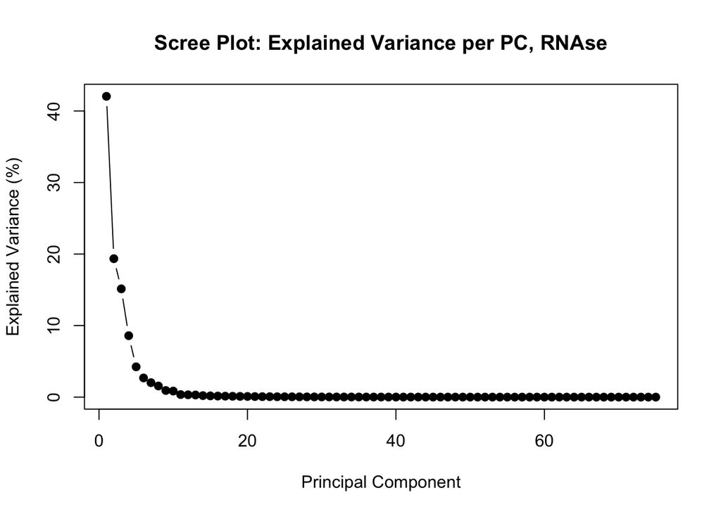

```r
#1. plot
plot(rnase_pca_ve_percent, type = "b", pch = 19,
     xlab = "Principal Component",
     ylab = "Explained Variance (%)",
     main = "Scree Plot: Explained Variance per PC, RNAse")
```

#barplot

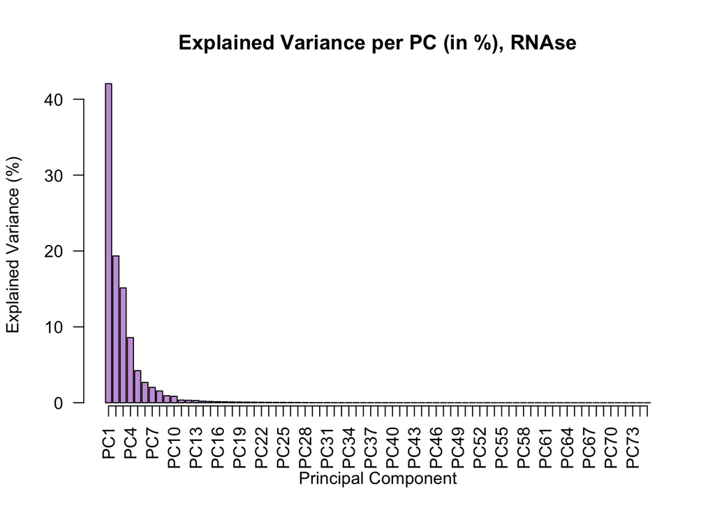

```r
#plot
bar_positions <- barplot(rnase_pca_ve_percent,
                         main = "Explained Variance per PC (in %), RNAse",
                         xlab = "Principal Component",
                         ylab = "Explained Variance (%)",
                         col = "#c9a0dc",
                        las = 2,
                         xaxt = "n")

axis(1, at = bar_positions, labels = paste0("PC", 1:length(rnase_pca_ve_percent)), las = 2)
```

#biplot

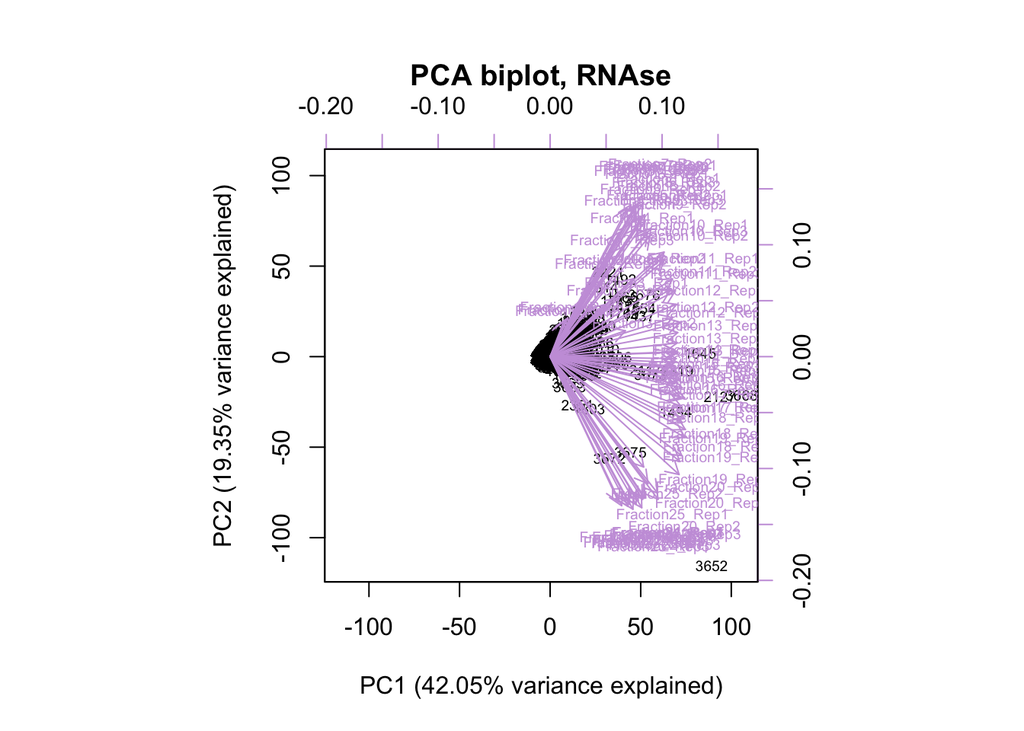

```r
#1. plot
biplot(rnase_pca, scale = 0, cex = 0.6,
       col = c("black", "#c9a0dc"),
       xlab = "PC1 (42.05% variance explained)",
       ylab = "PC2 (19.35% variance explained)",
       main="PCA biplot, RNAse")
```

#test graph

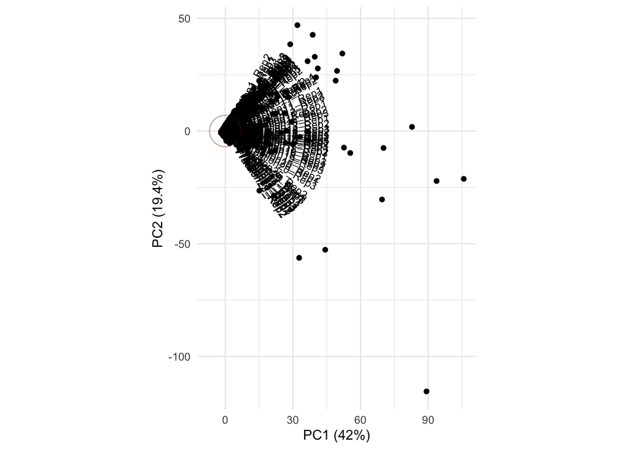

```r
library(ggbiplot)
#1. axis
my_var_explained <- c(42.05, 19.35)
#2. plot
ggbiplot(rnase_pca,
         obs.scale = 1,
         var.scale = 1,
         ellipse = FALSE,
         circle = TRUE,
         var.axes = TRUE) +
  xlab(paste0("PC1 (", round(my_var_explained[1], 1), "%)")) +
  ylab(paste0("PC2 (", round(my_var_explained[2], 1), "%)")) +
  theme_minimal()
```

###determine cluster #elbowplot Goal: determine what amount of clusters is suitable for K-means clustering

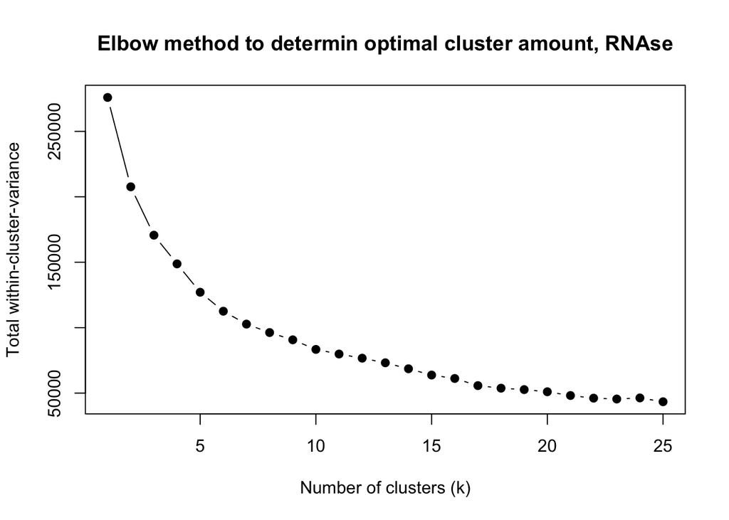

```r
#1. calculate wss: within-cluster sum of squares
wss <- sapply(1:25, function(k){
  kmeans(rnase_pca$x, centers = k, nstart = 25, iter.max = 50)$tot.withinss
})
#2. plot
plot(1:25, wss, type = "b", pch = 19,
     xlab = "Number of clusters (k)",
     ylab = "Total within-cluster-variance",
     main = "Elbow method to determin optimal cluster amount, RNAse")
```

#Interpretation: -> no clear bend, potentially at 2

#silhouette score Goal: determine what number of clusters is suitable for K-means clustering

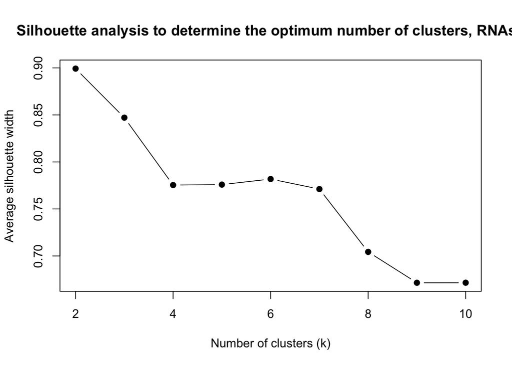

```r
# Silhouette analysis

library(cluster)
library(factoextra)

#1. Extract PCA-transformed data
rnase_sil_df <- rnase_pca$x

#2. Placeholder for average silhouette widths
rnase_avg_sil <- numeric(length = 9)

# 3. Calculate silhouette scores for different k values
k_values <- 2:10
for (i in seq_along(k_values)) {
  k <- k_values[i]
  rnase_km <- kmeans(rnase_sil_df, centers = k, nstart = 25)
  rnase_ss <- silhouette(rnase_km$cluster, dist(rnase_sil_df))
  rnase_avg_sil[i] <- mean(rnase_ss[, 3])
}

# 4. Plot similar to elbow method
plot(k_values, rnase_avg_sil, type = "b", pch = 19,
     xlab = "Number of clusters (k)",
     ylab =  "Average silhouette width",
     main = "Silhouette analysis to determine the optimum number of clusters, RNAse")
```

```
##   cluster size ave.sil.width
## 1       1 3619          0.92
## 2       2   61         -0.17
```

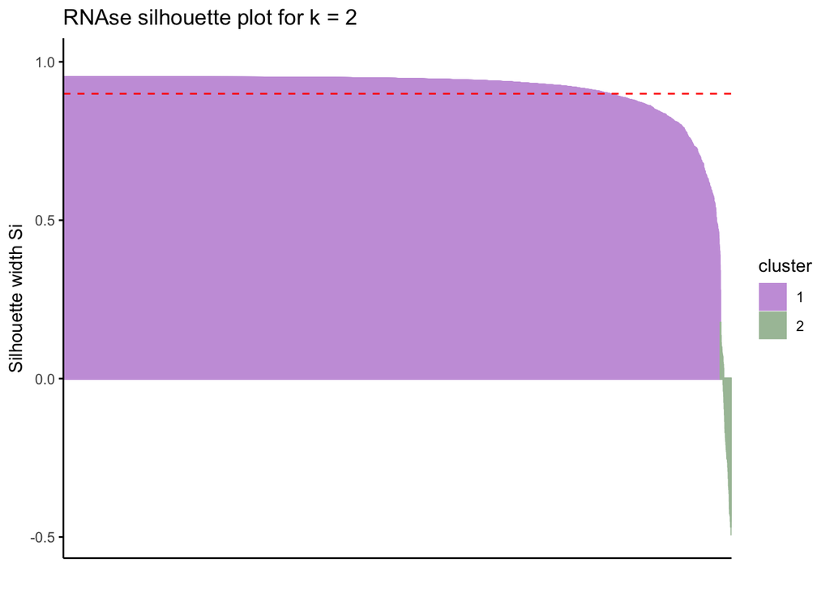

```r
# 5. Identify the best k based on max silhouette width
best_k <- k_values[which.max(rnase_avg_sil)]

# 6. Run K-Means and compute the  silhouette for the best k
rnase_km_best <- kmeans(rnase_sil_df, centers = best_k, nstart = 25)
rnase_best_sil <- silhouette(rnase_km_best$cluster, dist(rnase_sil_df))

# 7. Visualize silhouette plot
palette_colors <- c("#c9a0dc", "#A9C1A6", "#F5E1A4")[1:best_k]

fviz_silhouette(
  rnase_best_sil,
  palette = palette_colors,
  ggtheme = theme_classic(),
  main = paste("RNAse silhouette plot for k =", best_k)
)
```

#Interpretation k=2 seems most suitable

###kmeans Goal:divide dataset into k cluster to understand grouping and potentionally find biological relations

#apply K-means rnase

```r
#1. apply kmeans to  data set
# using k=2
#kmeans runs 25 and uses best result
R_kmeans_result <- kmeans(rnase_pca$x, centers = 2, nstart = 25)
```

```r
#1. in which cluster every obserbation is assigned to
head(R_kmeans_result$cluster)
```

```
## [1] 1 1 1 1 1 1
```

```r
#2. Coordinates the cluster center
head(R_kmeans_result$centers)
```

```
##          PC1         PC2         PC3         PC4         PC5          PC6
## 1 -0.5538796 -0.06905454 -0.01090159 -0.02630975 -0.01289743 -0.001613832
## 2 32.8604940  4.09685861  0.64676796  1.56090165  0.76517732  0.095745224
##            PC7         PC8         PC9        PC10          PC11         PC12
## 1  0.006436578  0.00302147  0.00254597  0.01011415 -0.0005686247 -0.001769798
## 2 -0.381868448 -0.17925739 -0.15104698 -0.60005094  0.0337352911  0.104998362
##           PC13         PC14         PC15          PC16         PC17
## 1  0.004656205 -0.003991235  0.001960089 -0.0001981682 -0.001978496
## 2 -0.276242721  0.236791487 -0.116287889  0.0117568969  0.117379936
##           PC18        PC19         PC20         PC21          PC22
## 1  0.000431136 -0.00154620  0.001330626  0.003735507  3.544999e-05
## 2 -0.025578380  0.09173278 -0.078943178 -0.221619680 -2.103172e-03
##            PC23        PC24         PC25          PC26          PC27
## 1 -0.0004491628 -0.00130619 -0.000370916  0.0007849293 -0.0009418668
## 2  0.0266478728  0.07749347  0.022005659 -0.0465681844  0.0558789525
##            PC28        PC29         PC30          PC31          PC32
## 1 -0.0001698448 -0.00076388  0.000641797 -0.0001886109  7.418319e-05
## 2  0.0100765306  0.04531937 -0.038076448  0.0111898803 -4.401131e-03
##            PC33          PC34          PC35          PC36          PC37
## 1  9.106565e-05 -0.0001725814 -0.0003788745  0.0005600416 -0.0001765544
## 2 -5.402731e-03  0.0102388866  0.0224778157 -0.0332260719  0.0104745963
##            PC38          PC39        PC40          PC41          PC42
## 1 -0.0001364014  9.293676e-05 -0.00040160  0.0004443593 -0.0002138616
## 2  0.0080924067 -5.513740e-03  0.02382607 -0.0263628910  0.0126879522
##            PC43          PC44          PC45          PC46          PC47
## 1  0.0004490269 -0.0003666229  6.227416e-05 -0.0004030205  0.0001989351
## 2 -0.0266398110  0.0217509524 -3.694593e-03  0.0239103482 -0.0118023935
##            PC48          PC49          PC50          PC51          PC52
## 1 -0.0003027435  0.0004880938  2.993245e-05 -0.0001941524 -0.0001565559
## 2  0.0179611280 -0.0289575668 -1.775829e-03  0.0115186499  0.0092881275
##           PC53          PC54          PC55          PC56          PC57
## 1  0.000248212 -0.0002825603  0.0002988513 -0.0000316154  0.0001855104
## 2 -0.014725889  0.0167637001 -0.0177302089  0.0018756740 -0.0110059369
##            PC58         PC59          PC60          PC61          PC62
## 1  2.897406e-06  0.000078756  4.503042e-07 -0.0001067423 -2.227005e-05
## 2 -1.718969e-04 -0.004672425 -2.671559e-05  0.0063327948  1.321235e-03
##            PC63          PC64          PC65          PC66          PC67
## 1 -7.271752e-05 -1.063962e-05 -1.410303e-05  9.618385e-05 -3.651899e-05
## 2  4.314176e-03  6.312260e-04  8.367028e-04 -5.706383e-03  2.166594e-03
##            PC68          PC69          PC70          PC71          PC72
## 1  0.0000108066  5.080944e-06 -1.908735e-05 -1.764747e-05 -2.622503e-06
## 2 -0.0006411328 -3.014416e-04  1.132412e-03  1.046987e-03  1.555875e-04
##            PC73         PC74          PC75
## 1 -2.713061e-16 2.478677e-16  6.259765e-16
## 2  7.837762e-15 2.440857e-15 -3.177154e-14
```

```r
#3. shows how compact the clusters are using WSS
# lower WSS means a more compact cluster
R_kmeans_result$tot.withinss
```

```
## [1] 207640.2
```

#K-means Plot rnase

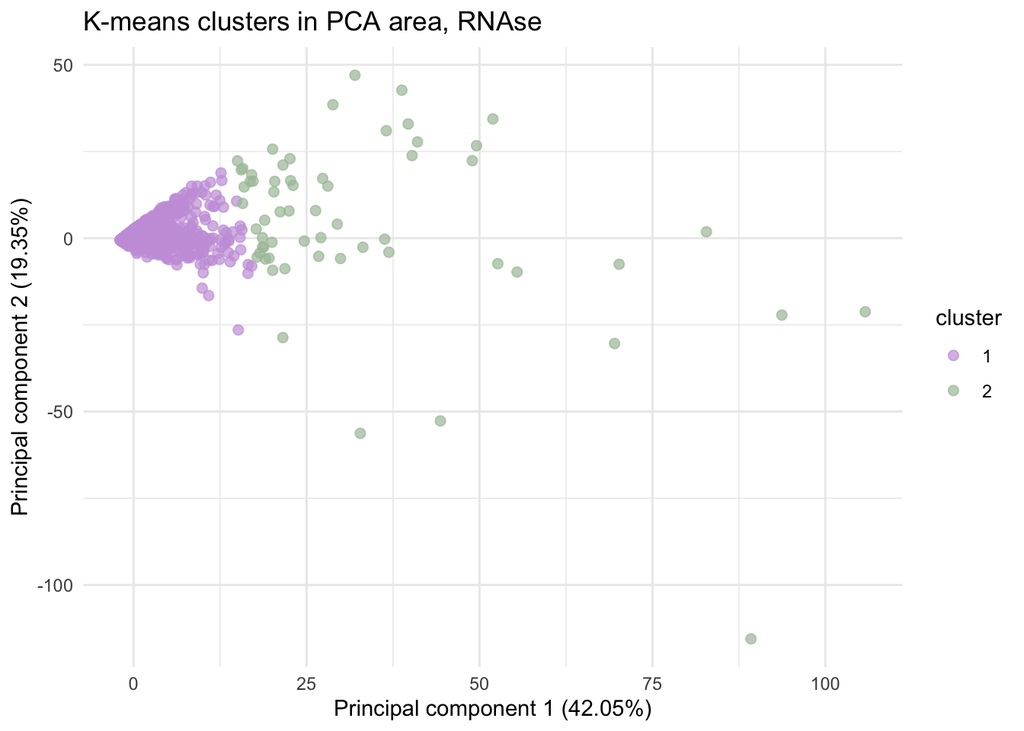

```r
#1. prepare data
#save pca matrix into data frame
# add cluster column
rnase_data <- as.data.frame(rnase_pca$x)
rnase_data$cluster <- as.factor(R_kmeans_result$cluster)

#2. plot
library(ggplot2)

ggplot(rnase_data, aes(x = PC1, y = PC2, color = cluster)) +
  geom_point(alpha = 0.7, size = 2) +
  labs(title = "K-means clusters in PCA area, RNAse",
       x = "Principal component 1 (42.05%)",
       y = "Principal component 2 (19.35%)") +
  theme_minimal() +
  scale_color_manual(values = c("#c9a0dc","#A9C1A6"))
```

#plot PC1 and PC2 as control

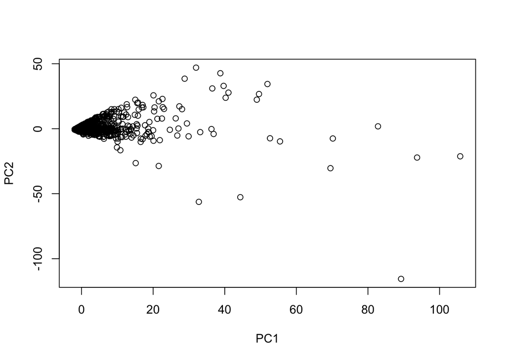

```r
first_two_components <- rnase_data[,1:2]
plot(first_two_components)
```

###right shift

```r
#create dataframe with right shift proteins only
# convert matrices to dataframes
corrected_ctrl_df <- as.data.frame(S_corrected_expr_ctrl, stringsAsFactors = FALSE)
corrected_rnase_df <- as.data.frame(S_corrected_expr_rnase, stringsAsFactors = FALSE)

# add column with protein names to newly created dataframes
corrected_ctrl_with_protein <- cbind(Protein = protein_names, corrected_ctrl_df)
corrected_rnase_with_protein <- cbind(Protein = protein_names, corrected_rnase_df)

# filter for matching columns between right_shift_proteins_df and the batch removed dataframes
right_shift_ctrl <- corrected_ctrl_df[corrected_ctrl_with_protein$Protein %in% right_shift_proteins_df$Protein, ]
right_shift_rnase <- corrected_rnase_df[corrected_rnase_with_protein$Protein %in% right_shift_proteins_df$Protein, ]
```

### label rsp in larger pca

Goal: highlight right shifts proteins in a visualization of PC1 and PC2 to determine biological relation

##rnase labeling

```r
library(ggplot2)

#1. prepare PCA, extract numerical values
test_rnase_df <- as.data.frame(percent_rnase_df[,-1])
TR_pca_result <- prcomp(test_rnase_df, center = TRUE, scale. = TRUE)

#2. convert PCA results into dataframe
TR_pca_df <- as.data.frame(TR_pca_result$x)

#3. copy protein names from rownames
TR_pca_df$Protein <- percent_rnase_df$Protein

#4. define righ shift proteins
test_highlight_proteins <- right_shift_proteins_df$Protein

#5. add column with highlights
TR_pca_df$Highlight <- ifelse(TR_pca_df$Protein %in% test_highlight_proteins, "Yes", "No")
unique(TR_pca_df$Highlight)
```

```
## [1] "No"  "Yes"
```

```r
#6. show how many right shift proteins were detected
table(TR_pca_df$Highlight)
```

```
##
##   No  Yes
## 3540  140
```

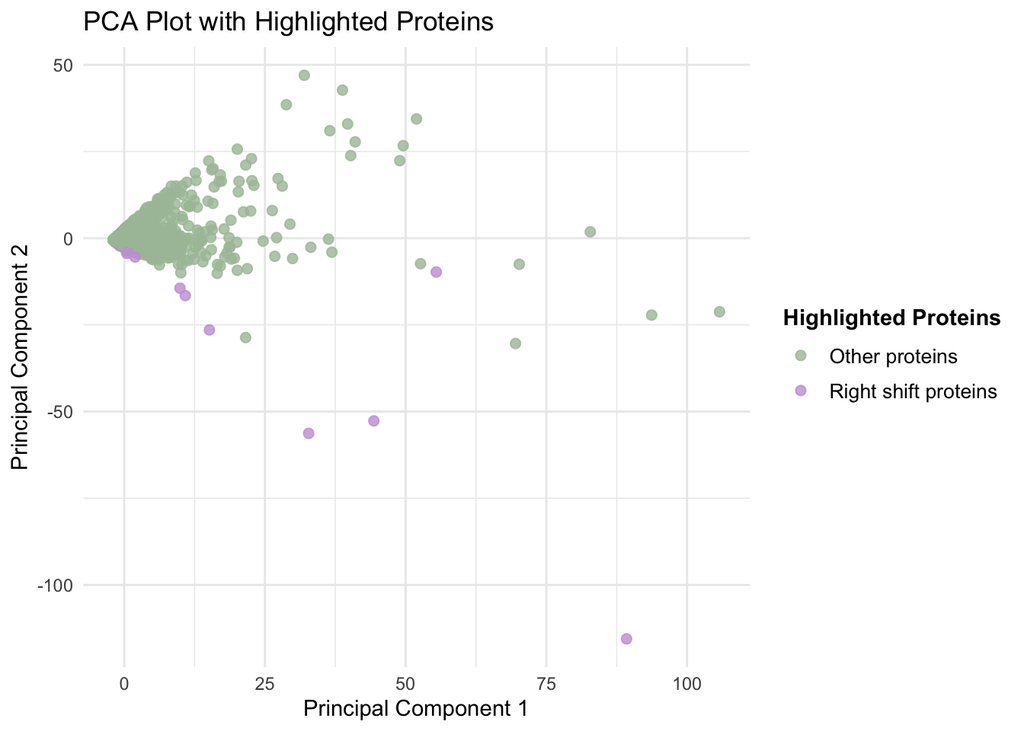

```r
#7. plot
ggplot(TR_pca_df, aes(x = PC1, y = PC2, color = Highlight)) +
  geom_point(alpha = 0.8, size = 2) +
  scale_color_manual(
  values = c("Yes" = "#c9a0dc", "No" = "#A9C1A6"),
  name = "Highlighted Proteins",
  labels = c("Yes" = "Right shift proteins", "No" = "Other proteins")
) +
  labs(title = "PCA Plot with Highlighted Proteins",
       x = "Principal Component 1",
       y = "Principal Component 2") +
  theme_minimal()+
  theme(
    legend.position = "right",
    legend.title = element_text(face = "bold"),
    legend.text = element_text(size = 10)
  )
```

##ctrl

```r
library(ggplot2)

#1. prepare PCA, extract numerical values
test_ctrl_df <- as.data.frame(percent_ctrl_df[,-1])
TC_pca_result <- prcomp(test_ctrl_df, center = TRUE, scale. = TRUE)

#2. convert PCA results into dataframe
TC_pca_df <- as.data.frame(TC_pca_result$x)

#3. copy protein names from rownames
TC_pca_df$Protein <- percent_ctrl_df$Protein

#4. define righ shift proteins
test_highlight_proteins <- right_shift_proteins_df$Protein

#5. add column with highlights
TC_pca_df$Highlight <- ifelse(TC_pca_df$Protein %in% test_highlight_proteins, "Yes", "No")
unique(TC_pca_df$Highlight)
```

```
## [1] "No"  "Yes"
```

```r
#6. show how many right shift proteins were detected
table(TC_pca_df$Highlight)
```

```
##
##   No  Yes
## 3540  140
```

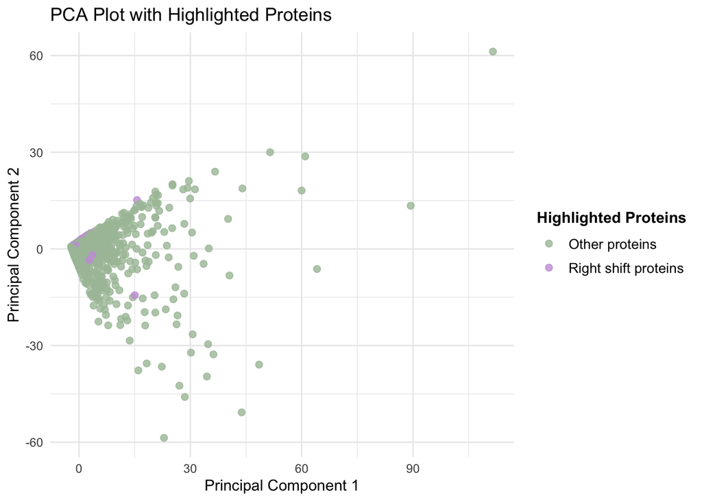

```r
#7. plot
ggplot(TC_pca_df, aes(x = PC1, y = PC2, color = Highlight)) +
  geom_point(alpha = 0.8, size = 2) +
  scale_color_manual(
  values = c("Yes" = "#c9a0dc", "No" = "#A9C1A6"),
  name = "Highlighted Proteins",
  labels = c("Yes" = "Right shift proteins", "No" = "Other proteins")
) +
  labs(title = "PCA Plot with Highlighted Proteins",
       x = "Principal Component 1",
       y = "Principal Component 2") +
  theme_minimal()+
  theme(
    legend.position = "right",
    legend.title = element_text(face = "bold"),
    legend.text = element_text(size = 10)
  )
```

##label RNA binding proteins in K-means

#isolate rbp

```r
# Select only relevant columns from the RBP and Non-RBP tables
rbp_subset <- Table_HS_RBP[, c("Entry_Name", "pI", "Mass_kDa" , "Length_AA")]
non_rbp_subset <- Table_HS_Non_RBP[, c("Entry_Name", "pI", "Mass_kDa", "Length_AA")]

# Combine both subsets into a single table
Table_HS_Combined <- rbind(rbp_subset, non_rbp_subset)

# # 3. Merge: Proteinname-Spalten heißen unterschiedlich -> by.x / by.y verwenden
merged_df <- merge(test_scores_combined_df, Table_HS_Combined,
                   by.x = "Protein", by.y = "Entry_Name",
                   all.x = TRUE)  # keep all entries from test_scores_combined_df
#depict result
dim(merged_df)
```

```
## [1] 3680   14
```

```r
#1.filter for RBPs
merged_df <- merge(test_scores_combined_df, Table_HS_Combined,
                   by.x = "Protein", by.y = "Entry_Name",
                   all.x = TRUE)
df_complete <- merged_df[complete.cases(merged_df[, c("probability", "pI", "Mass_kDa")]), ]
df_complete$RBP_shift_category <- ifelse(df_complete$probability >= optimal_threshold,
                                         ifelse(df_complete$Shift_direction_ctrl_to_rnase == "left shift", "RBP_left",
                                                ifelse(df_complete$Shift_direction_ctrl_to_rnase == "right shift", "RBP_right", "RBP")),
                                         "Non-RBP")

rbp_only <- df_complete[df_complete$RBP_shift_category %in% c("RBP_left", "RBP_right"), ]

#2.extract RBPS and store in a separate vector
rbp_proteins <- rbp_only$Protein
```

#K-means ctrl

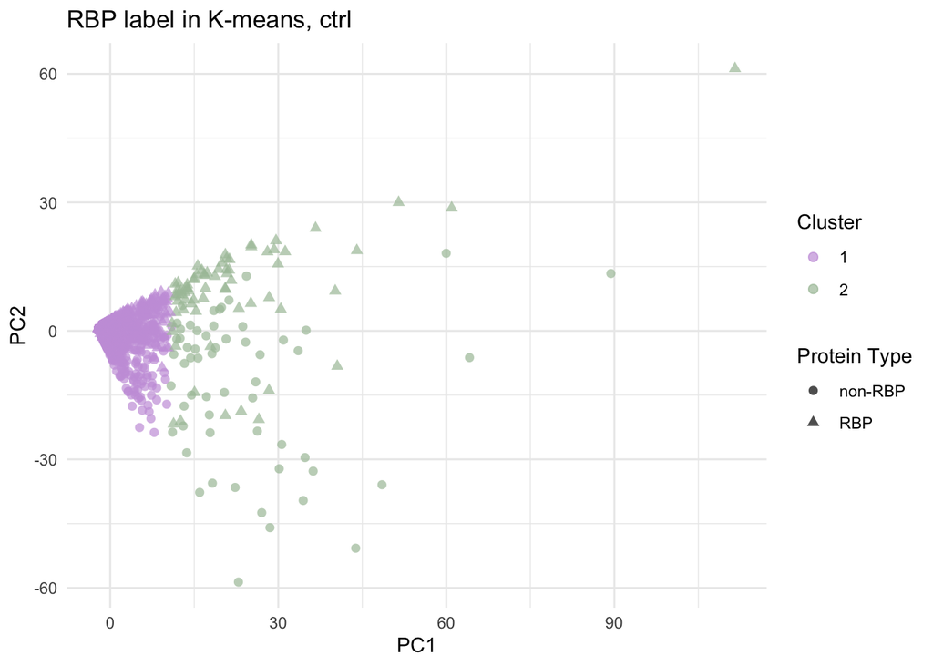

```r
# Convert PCA ctrl data into dataframe
Ctrl_data <- as.data.frame(ctrl_pca$x)
Ctrl_data$cluster <- as.factor(C_kmeans_result$cluster)

# Isolate protein names
Ctrl_data$protein_name <- percent_ctrl_df$Protein

# Check if protein is an RBP
Ctrl_data$is_rbp <- Ctrl_data$protein_name %in% rbp_proteins

# Convert logical to labeled factor
Ctrl_data$protein_type <- factor(Ctrl_data$is_rbp,
                                 levels = c(FALSE, TRUE),
                                 labels = c("non-RBP", "RBP"))

# 5. Plot with shape based on labeled protein type
library(ggplot2)

ggplot(Ctrl_data, aes(x = PC1, y = PC2, color = cluster, shape = protein_type)) +
  geom_point(alpha = 0.7, size = 2) +
  labs(title = "RBP label in K-means, ctrl",
       x = "PC1",
       y = "PC2",
       color = "Cluster",
       shape = "Protein Type") +
  theme_minimal() +
  scale_shape_manual(values = c("non-RBP" = 16, "RBP" = 17)) +
  scale_color_manual(values = c("1" = "#c9a0dc", "2" = "#A9C1A6"))
```

#K-means rnase

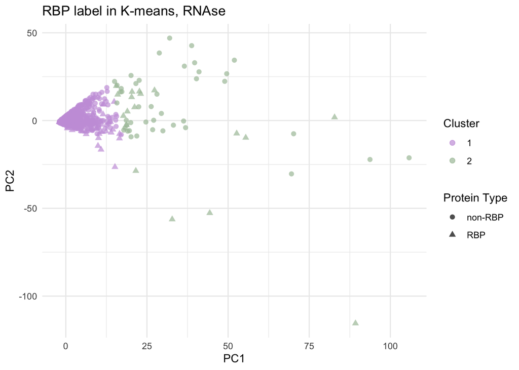

```r
## 1. Convert PCA RNAse data into dataframe
rnase_data <- as.data.frame(rnase_pca$x)
rnase_data$cluster <- as.factor(R_kmeans_result$cluster)

# 2. Isolate protein names
rnase_data$protein_name <- S_corrected_expr_rnase_df$Protein

# 3. Check if protein is an RBP and relabel
rnase_data$is_rbp <- rnase_data$protein_name %in% rbp_proteins
rnase_data$protein_type <- factor(rnase_data$is_rbp,
                                  levels = c(FALSE, TRUE),
                                  labels = c("non-RBP", "RBP"))

# 4. Plot with labeled protein type
library(ggplot2)

ggplot(rnase_data, aes(x = PC1, y = PC2, color = cluster, shape = protein_type)) +
  geom_point(alpha = 0.7, size = 2) +
  labs(title = "RBP label in K-means, RNAse",
       x = "PC1",
       y = "PC2",
       color = "Cluster",
       shape = "Protein Type") +
  theme_minimal() +
  scale_shape_manual(values = c("non-RBP" = 16, "RBP" = 17)) +
  scale_color_manual(values = c("1" = "#c9a0dc", "2" = "#A9C1A6"))
```

###CHI squared test

Goal: Determine if cluster are associated with RNA binding proteins

#rnase

```r
#1. Add protein column
rnase_data$protein_name <-  c(percent_rnase_df$Protein)

#2.set TRUE to RBP and FALSE to non - RBP
rnase_data$is_rbp <- rnase_data$protein_name %in% rbp_proteins
#3.turn cluster into a factor
rnase_data$cluster <- factor(rnase_data$cluster, levels = c(1, 2))
#keep cluster as order
```

```r
#1. create table which sorts RBPs and non-RBPs into clusters
r_tbl <- table(rnase_data$is_rbp, rnase_data$cluster)
show(r_tbl)
```

```
##
##            1    2
##   FALSE 2907   43
##   TRUE   712   18
```

```r
#1.table counts the amount of RBPs
table(rnase_data$is_rbp)
```

```
##
## FALSE  TRUE
##  2950   730
```

```r
str(rnase_data$is_rbp)
```

```
##  logi [1:3680] FALSE FALSE FALSE TRUE FALSE TRUE ...
```

```r
#1. apply chi sqquared to earlier created table
chisq.test(r_tbl)
```

```
##
##  Pearson's Chi-squared test with Yates' continuity correction
##
## data:  r_tbl
## X-squared = 3.0562, df = 1, p-value = 0.08043
```

#Interpretation: p=0.08043 > 0.05 -> non-significant

##ctrl

```r
#1. Add protein column
Ctrl_data$protein_name <-  c(percent_ctrl_df$Protein)
#2.set TRUE to RBP and FALSE to non - RBP
Ctrl_data$is_rbp <- Ctrl_data$protein_name %in% rbp_proteins
#3.turn cluster into a factor
Ctrl_data$cluster <- factor(Ctrl_data$cluster, levels = c(1, 2))
#keep cluster as order
```

```r
#1. create table which sorts RBPs and non-RBPs into clusters
c_tbl <- table(Ctrl_data$is_rbp, Ctrl_data$cluster)
show(c_tbl)
```

```
##
##            1    2
##   FALSE 2892   58
##   TRUE   659   71
```

```r
#1.table counts the amount of RBPs
table(Ctrl_data$is_rbp)
```

```
##
## FALSE  TRUE
##  2950   730
```

```r
str(Ctrl_data$is_rbp)
```

```
##  logi [1:3680] FALSE FALSE FALSE TRUE FALSE TRUE ...
```

```r
#1. apply chi sqquared to earlier created table
chisq.test(c_tbl)
```

```
##
##  Pearson's Chi-squared test with Yates' continuity correction
##
## data:  c_tbl
## X-squared = 101.89, df = 1, p-value < 2.2e-16
```

#Interpretation’ p=2.2e-16 < 0.05 -> significant: there is a connection between clusters found through PCA and classification of proteins as RBPs